# SRF Arena: Wer redet am meisten?

Digital Democracy Lab

27 April 2019

Ein erster Einblick in die Untertitel der [SRF Arena](https://www.srf.ch/sendungen/arena): wer redet eigentlich am meisten, welche Partei redet am häufigsten, und welche Entwicklungen haben sich in den letzten Jahren ergeben?

Die Daten sind eine Zusammenstellung aus der [Mediendatenbank FARO](https://medienarchiv.srf.ch/FarowebSRF/Pages/LoggedIn/Login.aspx), den Teletext-Untertiteln von [SWISS TXT](https://www.swisstxt.ch/de/) sowie einer Nacherfassung durch das [Digital Democracy Lab](https://digdemlab.io) der Universität Zürich. Die Auswertungen wurden vom Team des Digital Democracy Lab durchgeführt.

Die Auswertungen erfolgen mit [R](https://r-project.org/) und [RStudio](https://www.rstudio.com/) und basieren beispielsweise auf den Packages [quanteda](https://quanteda.io) und [ggplot2](https://ggplot2.tidyverse.org).

# Lizenz

Die folgende Auswertung sowie die zur Verfügung gestellten, nacherfassten Daten sind unter der Lizenz [CC BY SA 4.0](https://creativecommons.org/licenses/by-sa/4.0/) frei verfügbar und verwendbar, unter den Bedingungen der Nennung des Digital Democracy Labs sowie dass die daraus erstellten Werke und Datensätze mit derselben Lizenz weiter geteilt werden.

This work is licensed under a [Creative Commons Attribution-ShareAlike 4.0 International License](http://creativecommons.org/licenses/by-sa/4.0/).

# Vorbereitung

```r
knitr::opts_chunk$set(echo = TRUE, message = FALSE, error = FALSE,
                      warning = FALSE, cache = FALSE)

if (!require("pacman", quietly = TRUE)) install.packages("pacman")
pacman::p_load('tidyverse','magrittr','lubridate','quanteda','DT','xml2')

theme_ddl <- theme_minimal() +
    theme(plot.title = element_text(size = 18, face = "bold"),
          plot.subtitle = element_text(size = 16),
          plot.caption = element_text(size = 13),
          axis.text = element_text(size = 14),
          axis.title = element_text(size = 15),
          strip.text =  element_text(size = 15),
          legend.text = element_text(size = 13),
          legend.title = element_text(size = 14))
```

# Daten

```r
# Rohdaten laden (noch nicht öffentlich) --------------------------------------

dtut <- readRDS("data_srf_arena_raw.rds")
```

Die Daten verfügen über folgende Struktur:

# Vorbereitung der Auswertung

```r
# Parteien --------------------------------------------------------------------

dtut %<>%
  mutate(
    partei = case_when(
      str_detect(funktion, "\\bSVP") ~ "SVP",
      str_detect(funktion, "\\b(SP|JUSO|Juso)") ~ "SP",
      str_detect(funktion, "\\b(FDP|Jungfreisinnige)") ~ "FDP",
      str_detect(funktion, "\\bCVP") ~ "CVP",
      str_detect(funktion, "\\b(Grüne|GPS)") ~ "Grüne",
      str_detect(funktion, "\\b(GLP|GPL|Grünliberale)") ~ "GLP",
      str_detect(funktion, "\\bBDP") ~ "BDP",
      str_detect(funktion, "\\bEVP") ~ "EVP",
      str_detect(funktion, "\\bEDU") ~ "EDU",
      str_detect(funktion, "\\bCSP") ~ "CSP",
      str_detect(funktion, "\\bPiratenpartei") ~ "PPS",
      str_detect(funktion, "\\bUP") ~ "UP",
      str_detect(funktion, "\\bLega\\b") ~ "Lega",
      str_detect(funktion, "\\bparteilos") ~ "parteilos",
      str_detect(funktion, "\\b(Bundesr|Bundespr)") ~ "Bundesrat"
    ),
    jungpartei = ifelse(
      str_detect(funktion, "\\b(Jung|JUSO|Juso)") & !is.na(partei), 1, 0),
    partei = ifelse(is.na(partei) & rolle == "Experte", "ExpertIn", partei),
    partei = ifelse(is.na(partei) & rolle == "Zuschauer", "ZuschauerIn", partei),
    partei = ifelse(is.na(partei) & rolle == "Diskutant", "andere", partei),
    jahr = year(sendedatum)
  )


# Parteien und ihre Farben ----------------------------------------------------

parties <- c("SVP", "SP", "FDP", "CVP", "Grüne", "GLP", "BDP",
             "Bundesrat", "ExpertIn", "ZuschauerIn")

parties2 <- c(parties,  "andere")

parties_col <- c("#3F7B17", "#EE2A3B", "#104FA0", "#FF850C",
                 "#84B414", "#C3D93F", "#FFDD00",
                 "grey15", "grey35", "grey55", "grey75")


# Quanteda-Corpus erstellen ---------------------------------------------------

cp <- corpus(dtut, text_field = "statement")

docnames(cp) <- paste0(dtut$id, "_", dtut$id2)

res <- cp %>% summary(n = nrow(dtut)) # data frame mit beschreibenden Statistiken
```

# Welche Parteien reden am meisten?

In einer ersten Analyse wird die Gesprächsteilnahme pro Partei betrachtet. Dazu werden die Anzahl Wörter pro Partei verglichen. Summiert über alle verschiedenen Politikerinnen und Politiker der jeweiligen Partei, sowie allen Sendungen pro Jahr, zeigt sich somit ein Bild, welche Bühne die Parteien mit der SRF Arena erhalten (oder für sich beanspruchen, indem Sie mehr reden). Die Parteien sind dabei nach Stärke im Parlament sortiert.

Wichtig zu erwähnen ist, dass wir die Anzahl Wörter auswerten, nicht die gesprochene Zeit an sich. Die Moderation ist grundsätzlich ausgeschlossen, sodass nur die Gäste der Sendung angezeigt werden. Unter “anderen” Gästen sind viele verschiedene Personen summiert, beispielsweise VerbandsvertreterInnen (Bauernverband, Gewerkschaften oder Economiesuisse).

```r
# Anzahl an Worte pro Partei insgesamt  ---------------------------------------

wordntot <- res %>%
  filter(!is.na(partei)) %>%
  mutate(total = sum(Tokens)) %>%
  group_by(partei) %>%
  mutate(anteil = sum(Tokens) / total) %>%
  slice(1) %>%
  select(partei, anteil) %>%
  ungroup() %>%
  mutate(partei = ifelse(!partei %in% parties, "andere", partei)) %>%
  group_by(partei) %>%
  summarise(anteil = round(sum(anteil, na.rm = T), 4)) %>%
  ungroup() %>%
  mutate(partei = factor(partei, levels = parties2),
         facets = ifelse(partei %in% c("Bundesrat", "ExpertIn",
                                       "ZuschauerIn", "andere"),
                         "andere", "Parteien"),
         jahr = "overall") %>%
  select(partei, jahr, anteil, facets)
```

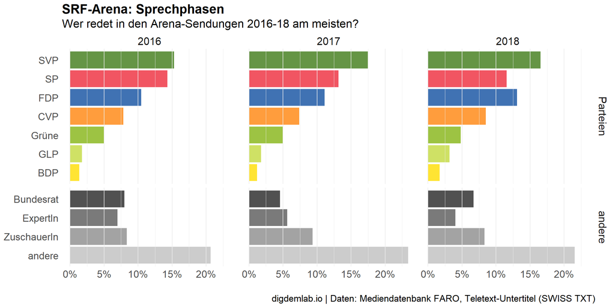

```r
# Anzahl an Worte pro Partei und Jahr  ----------------------------------------

wordn <- res %>%
  filter(!is.na(partei)) %>%
  group_by(jahr) %>%
  mutate(total = sum(Tokens)) %>%
  group_by(partei, jahr) %>%
  mutate(anteil = sum(Tokens) / total) %>%
  slice(1) %>%
  select(partei, jahr, anteil) %>%
  ungroup() %>%
  mutate(partei = ifelse(!partei %in% parties, "andere", partei)) %>%
  group_by(partei, jahr) %>%
  summarise(anteil = round(sum(anteil, na.rm = T), 4)) %>%
  ungroup() %>%
  mutate(partei = factor(partei, levels = parties2),
         facets = ifelse(partei %in% c("Bundesrat", "ExpertIn",
                                       "ZuschauerIn", "andere"),
                         "andere", "Parteien"))

wordn %>%
  ggplot(aes(fct_rev(partei), anteil, fill = partei)) +
    geom_col(alpha = 0.8) +
    scale_y_continuous(labels = scales::percent_format(accuracy = 1)) +
    scale_fill_manual(values = parties_col) +
    facet_grid(fct_rev(facets)~jahr, scales = "free_y", space = "free") +
    coord_flip() +
    labs(title = "SRF-Arena: Sprechphasen",
         subtitle = "Wer redet in den Arena-Sendungen 2016-18 am meisten?",
         caption = paste0("digdemlab.io | Daten: Mediendatenbank FARO,",
                          " Teletext-Untertitel (SWISS TXT)"),
         x = NULL, y = "") +
    theme_ddl +
    theme(legend.position = "none",
          panel.grid.major.y = element_blank(),
          panel.ontop = TRUE)
```

```r
# Tabelle
wordn %>% rbind(wordntot) %>%
    arrange(desc(facets), partei, jahr) %>%
    mutate(anteil = anteil * 100) %>%
    datatable(rownames = FALSE, colnames = c('Partei','Jahr','Prozentanteil','Gruppe'))
```

| Partei | Jahr | Prozentanteil | Gruppe |
| --- | --- | --- | --- |
| SVP | 2016 | 15.31 | Parteien |
| SVP | 2017 | 17.46 | Parteien |
| SVP | 2018 | 16.52 | Parteien |
| SVP | overall | 16.39 | Parteien |
| SP | 2016 | 14.3 | Parteien |
| SP | 2017 | 13.17 | Parteien |
| SP | 2018 | 11.56 | Parteien |
| SP | overall | 13.08 | Parteien |
| FDP | 2016 | 10.46 | Parteien |
| FDP | 2017 | 11.12 | Parteien |

[output cut: 34 more lines]

```r
# Grafik speichern
ggsave("201904_digdemlab_srfarena-parteien.png",
       dpi = 1200, width = 12, height = 6)
ggsave("201904_digdemlab_srfarena-parteien.pdf",
       dpi = 1200, width = 12, height = 6)
```

Die Anteile nach Sendung variieren dabei recht stark, wie folgender grober Überblick zeigt.

```r
p <- res %>%
  filter(!is.na(partei)) %>%
  group_by(sendedatum) %>%
  mutate(total = sum(Tokens)) %>%
  group_by(partei, sendedatum) %>%
  mutate(anteil = sum(Tokens) / total) %>%
  slice(1) %>%
  select(partei, sendedatum, anteil) %>%
  ungroup() %>%
  mutate(partei = ifelse(!partei %in% parties, "andere", partei)) %>%
  group_by(partei, sendedatum) %>%
  summarise(anteil = sum(anteil, na.rm = T)) %>%
  ungroup() %>%
  mutate(partei = factor(partei, levels = parties2)) %>%
  ggplot(aes(partei, anteil, fill = partei)) +
    geom_col(alpha = 0.8) +
    scale_y_continuous(labels = scales::percent_format(accuracy = 1)) +
    scale_fill_manual(values = parties_col) +
    facet_wrap(sendedatum~.) +
    labs(title = "SRF-Arena: Sprechphasen",
         subtitle = "Wer redet in den Arena-Sendungen 2016-18 am meisten?",
         caption = paste0("digdemlab.io | Daten: Mediendatenbank FARO,",
                          " Teletext-Untertitel (SWISS TXT)"),
         x = NULL, y = "") +
    theme_ddl +
    theme(legend.position = "none",
          axis.text = element_blank(),
          strip.text = element_text(size = 10))

ggsave(sm1 <- tempfile(fileext = ".svg"), p,
       width = 12, height = 12)
links <- with(res %>% select(url, sendedatum) %>%
                  mutate(url = as.character(url)) %>%
                  unique(),
              setNames(url, sendedatum))

xml <- read_xml(sm1)
xml %>%
  xml_find_all(xpath="//d1:text") %>%
  keep(xml_text(.) %in% names(links)) %>%
  xml_add_parent("a", "xlink:href" = links[xml_text(.)], target = "_blank")
write_xml(xml, sm2 <- tempfile(fileext = ".svg"))
```

Mehr Informationen zu den einzelnen Sendungen findet sich per Klick auf das Sendedatum.

[figure not shown]

```r
# Liste aller berücksichtigten und nacherfassten Sendungen --------------------
res %>%
    select(sendedatum, titel, url) %>%
    unique() %>%
    mutate(url = paste0('<a href="', url, '", target = "_blank">Sendungsinformation</a>')) %>%
    datatable(rownames = FALSE, escape = FALSE, colnames = c('Datum','Titel','Link'))
```

| Datum | Titel | Link |
| --- | --- | --- |
| 2016-01-08 | Präsidialarena | Sendungsinformation |
| 2016-01-15 | Abstimmungs-Arena: Initiative gegen Nahrungsmittelspekulation | Sendungsinformation |
| 2016-01-22 | Volkes Macht | Sendungsinformation |
| 2016-01-29 | Abstimmungs-Arena: Initiative gegen Heiratsstrafe | Sendungsinformation |
| 2016-02-05 | Abstimmungs-Arena: Durchsetzungsinitiative | Sendungsinformation |
| 2016-02-12 | Abstimmungs-Arena: Zweite Gotthardröhre | Sendungsinformation |
| 2016-02-19 | Zerrissene Schweiz | Sendungsinformation |
| 2016-02-26 | Brüssel greift an - wird die Schweiz nun entwaffnet? | Sendungsinformation |
| 2016-03-04 | Und jetzt Europa | Sendungsinformation |
| 2016-03-11 | Wer will Homo-Eltern? | Sendungsinformation |

[output cut: 116 more lines]

# Welche PolitikerInnen sind das?

Hinter diesen Parteien stecken Personen, welche das Wort ergriffen haben. Welche PolitikerInnen stechen insgesamt heraus?

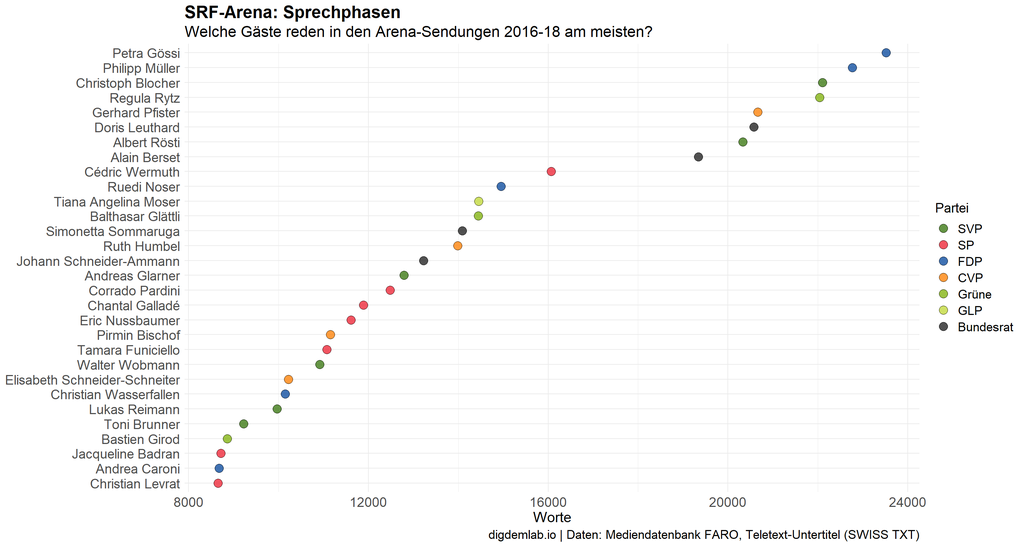

```r
top30 <- res %>%
  filter(!person %in% c("Anderes", "Off-Stimme", "Zuschauer 1",
                        "Jonas Projer", "Mario Grossniklaus")) %>%
  filter(anwesend == "ja") %>%
  group_by(partei, person) %>% summarise(worte = sum(Tokens)) %>%
  ungroup() %>%
  mutate(partei = factor(partei, levels = parties2)) %>%
  top_n(30, worte)

top30 %>%
  ggplot(aes(reorder(person, worte), worte, fill = partei)) +
  geom_point(shape = 21, size = 4, alpha = 0.8) +
  scale_fill_manual(values = parties_col[c(1:6,8)]) +
  coord_flip() +
  labs(title = "SRF-Arena: Sprechphasen",
       subtitle = "Welche Gäste reden in den Arena-Sendungen 2016-18 am meisten?",
       caption = paste0("digdemlab.io | Daten: Mediendatenbank FARO,",
                          " Teletext-Untertitel (SWISS TXT)"),
       x = NULL, y = "Worte",
       fill = "Partei") +
  theme_ddl
```

```r
top30 %>%
    arrange(desc(worte)) %>%
    datatable(rownames = FALSE, colnames = c('Partei','Person','Worte'))
```

| Partei | Person | Worte |
| --- | --- | --- |
| FDP | Petra Gössi | 23518 |
| FDP | Philipp Müller | 22766 |
| SVP | Christoph Blocher | 22106 |
| Grüne | Regula Rytz | 22041 |
| CVP | Gerhard Pfister | 20662 |
| Bundesrat | Doris Leuthard | 20575 |
| SVP | Albert Rösti | 20330 |
| Bundesrat | Alain Berset | 19342 |
| SP | Cédric Wermuth | 16070 |
| FDP | Ruedi Noser | 14951 |

[output cut: 20 more lines]

```r
# Grafik speichern
ggsave("201904_digdemlab_srfarena-personen.png",
       dpi = 1200, width = 15, height = 8)
ggsave("201904_digdemlab_srfarena-personen.pdf",
       dpi = 1200, width = 15, height = 8)
```

# Im Jahr 2018: wer spricht für Parteien?

Können die geredeten Wörter nach Parteien und nach Personen in einer Grafik dargestellt werden?

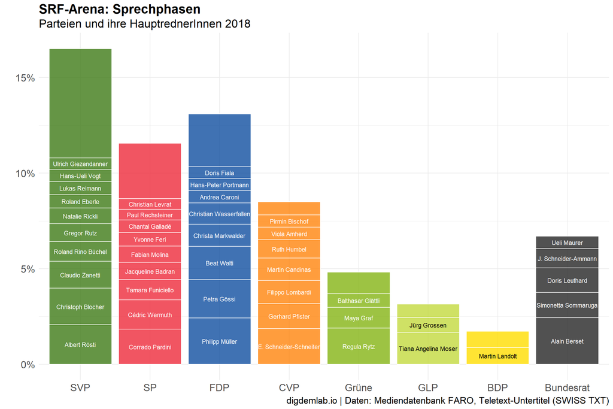

```r
prt18 <- res %>%
  filter(!is.na(partei)) %>%
  filter(jahr == 2018) %>%
  mutate(partei = ifelse(!partei %in% parties, "andere", partei)) %>%
  mutate(total = sum(Tokens)) %>%
  group_by(partei) %>%
  mutate(sumt = sum(Tokens),
         anteil = sumt / total) %>%
  slice(1) %>%
  select(partei, anteil, sumt, total) %>%
  ungroup() %>%
  mutate(partei = factor(partei, levels = parties2))


ppl18 <- res %>%
  filter(!is.na(partei)) %>%
  filter(jahr == 2018) %>%
  group_by(partei, person) %>%
  summarise(worte = sum(Tokens)) %>%
  filter(worte > 2000) %>%
  top_n(10, worte) %>%
  filter(!is.na(partei) & partei %in% parties & !partei %in% c("ExpertIn", "ZuschauerIn")) %>%
  mutate(person = ifelse(person == "Elisabeth Schneider-Schneiter",
                         "E. Schneider-Schneiter", person),
         person = ifelse(person == "Johann Schneider-Ammann",
                         "J. Schneider-Ammann", person))


prt18 %>%
  full_join(ppl18, by = "partei") %>%
  mutate(panteil = worte / total,
         partei = factor(partei, levels = parties2)) %>%
  assign("save", ., envir = .GlobalEnv) %>%
  group_by(partei) %>%
  mutate(pmissing = sumt - sum(worte),
         pmissinganteil = pmissing / total) %>%
  select(partei, pmissing, pmissinganteil) %>%
  unique() %>%
  mutate(person = "",
         worte = pmissing,
         panteil = pmissinganteil,
         andere = 1) %>%
  select(-starts_with("pm")) %>%
  ungroup() %>%
  rbind(save %>% select(partei, person, worte, panteil) %>% mutate(andere = 0)) %>%
  filter(!is.na(panteil)) %>%
  arrange(partei, andere, desc(panteil)) %>%
  group_by(partei) %>%
  mutate(lab_ypos = cumsum(panteil) - 0.5 * panteil,
         lab_col = ifelse(partei %in% c("GLP", "BDP"), "a", "b")) %>%
  ggplot() +
     geom_col(aes(partei, panteil, fill = partei), color = "white", alpha = 0.8) +
     geom_text(aes(partei, lab_ypos, label = person, color = lab_col), size = 3) +
     scale_y_continuous(labels = scales::percent_format(accuracy = 1)) +
     scale_fill_manual(values = parties_col) +
     scale_color_manual(values = c("#000000", "#FFFFFF")) +
     labs(title = "SRF-Arena: Sprechphasen",
          subtitle = "Parteien und ihre HauptrednerInnen 2018",
          caption = paste0("digdemlab.io | Daten: Mediendatenbank FARO,",
                           " Teletext-Untertitel (SWISS TXT)"),
          x = NULL, y = "") +
     theme_ddl +
     theme(legend.position = "none")
```

```r
# Grafik speichern
ggsave("201904_digdemlab_srfarena-merged.png",
       dpi = 1200, width = 12, height = 8)
ggsave("201904_digdemlab_srfarena-merged.pdf",
       dpi = 1200, width = 12, height = 8)
```

# Replikation mit den reduzierten Daten

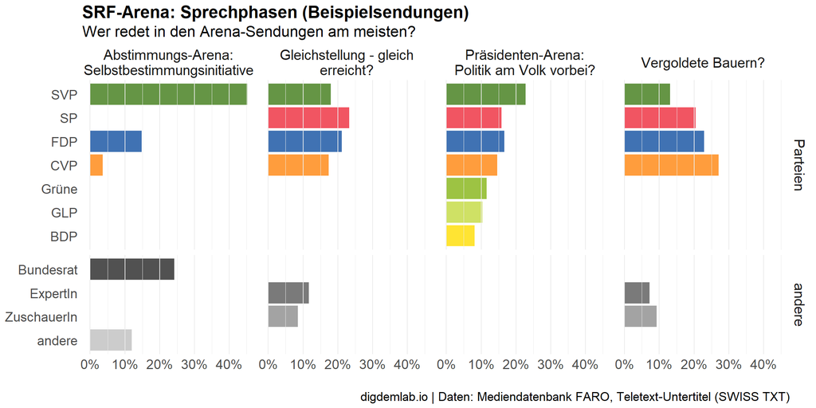

```r
# Auswahl der Sendungen erstellen ---------------------------------------------

dtut_red <- dtut %>%
  filter(id %in% c(352, 345, 322, 270))

saveRDS(dtut, "201904_digdemlab_repdata.rds") # Corpus für Replikation speichern


# Quanteda-Corpus erstellen ---------------------------------------------------

cp_red <- corpus(dtut_red, text_field = "statement")
docnames(cp_red) <-  paste0(dtut_red$id, "_", dtut_red$id2)

res_red <- cp_red %>% summary(n = nrow(dtut))


# Parteianteile in den Sendungen ----------------------------------------------

res_red %>%
  filter(!is.na(partei)) %>%
  group_by(titel) %>%
  mutate(total = sum(Tokens)) %>%
  group_by(partei, titel) %>%
  mutate(anteil = sum(Tokens) / total) %>%
  slice(1) %>%
  select(partei, titel, anteil) %>%
  ungroup() %>%
  mutate(partei = ifelse(!partei %in% parties, "andere", partei)) %>%
  group_by(partei, titel) %>%
  summarise(anteil = sum(anteil, na.rm = T)) %>%
  ungroup() %>%
  mutate(partei = factor(partei, levels = parties2),
         facets = ifelse(partei %in% c("Bundesrat", "ExpertIn",
                                       "ZuschauerIn", "andere"),
                         "andere", "Parteien")) %>%
  ggplot(aes(fct_rev(partei), anteil, fill = partei)) +
    geom_col(alpha = 0.8) +
    scale_y_continuous(labels = scales::percent_format(accuracy = 1)) +
    scale_fill_manual(values = parties_col) +
    facet_grid(fct_rev(facets)~titel, scales = "free_y", space = "free",
               labeller = label_wrap_gen(width=25)) +
    coord_flip() +
    labs(title = "SRF-Arena: Sprechphasen (Beispielsendungen)",
         subtitle = "Wer redet in den Arena-Sendungen am meisten?",
         caption = paste0("digdemlab.io | Daten: Mediendatenbank FARO,",
                          " Teletext-Untertitel (SWISS TXT)"),
         x = NULL, y = "") +
    theme_ddl +
    theme(legend.position = "none",
          panel.grid.major.y = element_blank(),
          panel.ontop = TRUE)
```

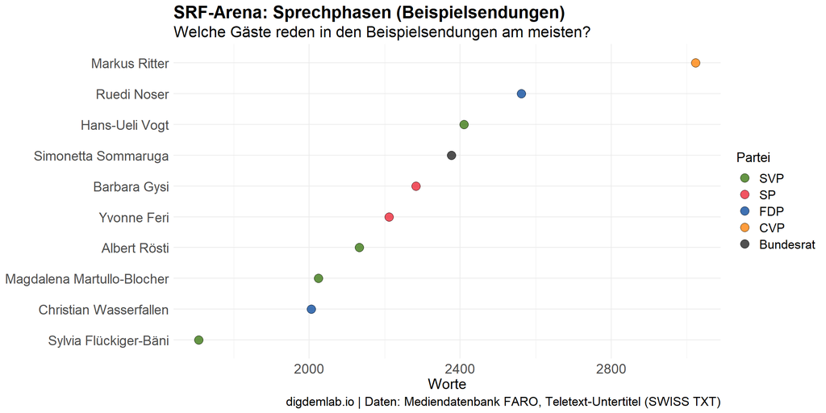

```r
# Redeumfang nach Person ------------------------------------------------------

res_red %>%
  filter(!person %in% c("Anderes", "Off-Stimme", "Zuschauer 1",
                        "Jonas Projer", "Mario Grossniklaus")) %>%
  filter(anwesend == "ja") %>%
  group_by(partei, person) %>% summarise(worte = sum(Tokens)) %>%
  ungroup() %>%
  mutate(partei = factor(partei, levels = parties2)) %>%
  top_n(10, worte) %>%
  ggplot(aes(reorder(person, worte), worte, fill = partei)) +
    geom_point(shape = 21, size = 4, alpha = 0.8) +
    scale_fill_manual(values = parties_col[c(1:4,8)]) +
    coord_flip() +
    labs(title = "SRF-Arena: Sprechphasen (Beispielsendungen)",
         subtitle = "Welche Gäste reden in den Beispielsendungen am meisten?",
         caption = paste0("digdemlab.io | Daten: Mediendatenbank FARO,",
                          " Teletext-Untertitel (SWISS TXT)"),
         x = NULL, y = "Worte",
         fill = "Partei") +
  theme_ddl
```